# H1N1 and Seasonal Flu Vaccines Prediction

Importing the Data and Analysing

```python
# importing the libraries
import pandas as pd
import numpy as np
import matplotlib.pyplot as plt
```

```python
# importing the datasets
f_train = pd.read_csv('./data/training_set_features.csv', index_col=0)
l_train = pd.read_csv('./data/training_set_labels.csv', index_col=0)
```

Now perform some preview of the datasets to gather some info

```python
# checking dataset info of the training features dataset
f_train.info()
```

```
<class 'pandas.core.frame.DataFrame'>
Int64Index: 26707 entries, 0 to 26706
Data columns (total 35 columns):
 #   Column                       Non-Null Count  Dtype
---  ------                       --------------  -----
 0   h1n1_concern                 26615 non-null  float64
 1   h1n1_knowledge               26591 non-null  float64
 2   behavioral_antiviral_meds    26636 non-null  float64
 3   behavioral_avoidance         26499 non-null  float64
 4   behavioral_face_mask         26688 non-null  float64
 5   behavioral_wash_hands        26665 non-null  float64
 6   behavioral_large_gatherings  26620 non-null  float64
 7   behavioral_outside_home      26625 non-null  float64
 8   behavioral_touch_face        26579 non-null  float64
 9   doctor_recc_h1n1             24547 non-null  float64
```

[output cut: 27 more lines]

```python
# checking dataset info of the training labels dataset
l_train.info()
```

```
<class 'pandas.core.frame.DataFrame'>
Int64Index: 26707 entries, 0 to 26706
Data columns (total 2 columns):
 #   Column            Non-Null Count  Dtype
---  ------            --------------  -----
 0   h1n1_vaccine      26707 non-null  int64
 1   seasonal_vaccine  26707 non-null  int64
dtypes: int64(2)
memory usage: 625.9 KB
```

```python
# previewing the training features datasets
f_train.head()
```

| respondent_id | h1n1_concern | h1n1_knowledge | behavioral_antiviral_meds | behavioral_avoidance | behavioral_face_mask | behavioral_wash_hands | behavioral_large_gatherings | behavioral_outside_home | behavioral_touch_face | doctor_recc_h1n1 | ... | income_poverty | marital_status | rent_or_own | employment_status | hhs_geo_region | census_msa | household_adults | household_children | employment_industry | employment_occupation |
| --- | --- | --- | --- | --- | --- | --- | --- | --- | --- | --- | --- | --- | --- | --- | --- | --- | --- | --- | --- | --- | --- |
| 0 | 1.0 | 0.0 | 0.0 | 0.0 | 0.0 | 0.0 | 0.0 | 1.0 | 1.0 | 0.0 | ... | Below Poverty | Not Married | Own | Not in Labor Force | oxchjgsf | Non-MSA | 0.0 | 0.0 | NaN | NaN |
| 1 | 3.0 | 2.0 | 0.0 | 1.0 | 0.0 | 1.0 | 0.0 | 1.0 | 1.0 | 0.0 | ... | Below Poverty | Not Married | Rent | Employed | bhuqouqj | MSA, Not Principle City | 0.0 | 0.0 | pxcmvdjn | xgwztkwe |
| 2 | 1.0 | 1.0 | 0.0 | 1.0 | 0.0 | 0.0 | 0.0 | 0.0 | 0.0 | NaN | ... | <= $75,000, Above Poverty | Not Married | Own | Employed | qufhixun | MSA, Not Principle City | 2.0 | 0.0 | rucpziij | xtkaffoo |
| 3 | 1.0 | 1.0 | 0.0 | 1.0 | 0.0 | 1.0 | 1.0 | 0.0 | 0.0 | 0.0 | ... | Below Poverty | Not Married | Rent | Not in Labor Force | lrircsnp | MSA, Principle City | 0.0 | 0.0 | NaN | NaN |
| 4 | 2.0 | 1.0 | 0.0 | 1.0 | 0.0 | 1.0 | 1.0 | 0.0 | 1.0 | 0.0 | ... | <= $75,000, Above Poverty | Married | Own | Employed | qufhixun | MSA, Not Principle City | 1.0 | 0.0 | wxleyezf | emcorrxb |

5 rows × 35 columns

```python
# previewing the training labels datasets
l_train.head()
```

| respondent_id | h1n1_vaccine | seasonal_vaccine |
| --- | --- | --- |
| 0 | 0 | 0 |
| 1 | 0 | 1 |
| 2 | 0 | 0 |
| 3 | 0 | 1 |
| 4 | 0 | 0 |

Introducing an assert in order to make sure that rows match ip in f_train and l_train dataframes. No error means nothing to look into

```python
np.testing.assert_array_equal(f_train.index.values, l_train.index.values)
```

Performing some Exploratory Data Analysis (EDA) to gather some relevant information for building the prediction model

First, looking into the distribution of the two target variables being H1N1 and Seasonal Vaccines

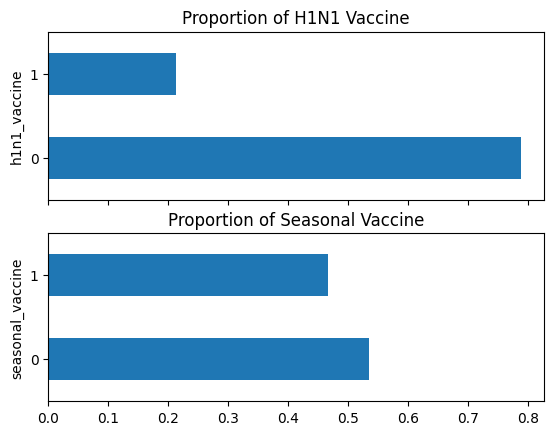

```python
fig, ax = plt.subplots(2, 1, sharex=True)
n_obs = l_train.shape[0]
(l_train['h1n1_vaccine']
    .value_counts()
    .div(n_obs)
    .plot.barh(title="Proportion of H1N1 Vaccine", ax=ax[0])
)
ax[0].set_ylabel("h1n1_vaccine")
(l_train['seasonal_vaccine']
    .value_counts()
    .div(n_obs)
    .plot.barh(title="Proportion of Seasonal Vaccine", ax=ax[1])
)
ax[1].set_ylabel("seasonal_vaccine")
plt.show()
```

It looks like roughy half of people received the seasonal flu vaccine, but only about 20% of people received the H1N1 flu vaccine. In terms of class balance, we say that the seasonal flu vaccine target has balanced classes, but the H1N1 flu vaccine target has moderately imbalanced classes.

Checking now if the two target variables are independent using the Phi Coefficient

```python
pd.crosstab(
    l_train["h1n1_vaccine"],
    l_train["seasonal_vaccine"],
    margins=True,
    normalize=True
)
```

| seasonal_vaccine h1n1_vaccine | 0 | 1 | All |
| --- | --- | --- | --- |
| 0 | 0.497810 | 0.289737 | 0.787546 |
| 1 | 0.036582 | 0.175871 | 0.212454 |
| All | 0.534392 | 0.465608 | 1.000000 |

```python
# Phi Coefficient
(l_train["h1n1_vaccine"]
    .corr(l_train["seasonal_vaccine"], method="pearson")
)
```

```
0.37714265306144684
```

Having a phi coefficient of 0.37 indicates a moderate positive correlation, meaning that most people who got an H1N1 flu vaccine also got the seasonal flu vaccine; while a minority of people who got the seasonal vaccine got the H1N1 vaccine, got H1N1 vaccine at a higher rate than those who did not get the seasonal vaccine.

Now merging the training features and labels dataset as a joint daframe for analysis

```python
j_train_back = f_train.join(l_train)
j_train = j_train_back #creating a backup variable
j_train.head()
```

| respondent_id | h1n1_concern | h1n1_knowledge | behavioral_antiviral_meds | behavioral_avoidance | behavioral_face_mask | behavioral_wash_hands | behavioral_large_gatherings | behavioral_outside_home | behavioral_touch_face | doctor_recc_h1n1 | ... | rent_or_own | employment_status | hhs_geo_region | census_msa | household_adults | household_children | employment_industry | employment_occupation | h1n1_vaccine | seasonal_vaccine |
| --- | --- | --- | --- | --- | --- | --- | --- | --- | --- | --- | --- | --- | --- | --- | --- | --- | --- | --- | --- | --- | --- |
| 0 | 1.0 | 0.0 | 0.0 | 0.0 | 0.0 | 0.0 | 0.0 | 1.0 | 1.0 | 0.0 | ... | Own | Not in Labor Force | oxchjgsf | Non-MSA | 0.0 | 0.0 | NaN | NaN | 0 | 0 |
| 1 | 3.0 | 2.0 | 0.0 | 1.0 | 0.0 | 1.0 | 0.0 | 1.0 | 1.0 | 0.0 | ... | Rent | Employed | bhuqouqj | MSA, Not Principle City | 0.0 | 0.0 | pxcmvdjn | xgwztkwe | 0 | 1 |
| 2 | 1.0 | 1.0 | 0.0 | 1.0 | 0.0 | 0.0 | 0.0 | 0.0 | 0.0 | NaN | ... | Own | Employed | qufhixun | MSA, Not Principle City | 2.0 | 0.0 | rucpziij | xtkaffoo | 0 | 0 |
| 3 | 1.0 | 1.0 | 0.0 | 1.0 | 0.0 | 1.0 | 1.0 | 0.0 | 0.0 | 0.0 | ... | Rent | Not in Labor Force | lrircsnp | MSA, Principle City | 0.0 | 0.0 | NaN | NaN | 0 | 1 |
| 4 | 2.0 | 1.0 | 0.0 | 1.0 | 0.0 | 1.0 | 1.0 | 0.0 | 1.0 | 0.0 | ... | Own | Employed | qufhixun | MSA, Not Principle City | 1.0 | 0.0 | wxleyezf | emcorrxb | 0 | 0 |

5 rows × 37 columns

Now using a Heatmap to plot correlations between features. That will be useful to select the most important features for building the prediction model.

First, dropping all non float or int values and NAN rows

```python
j_train = j_train.select_dtypes(exclude='object')
j_train = j_train.dropna()
```

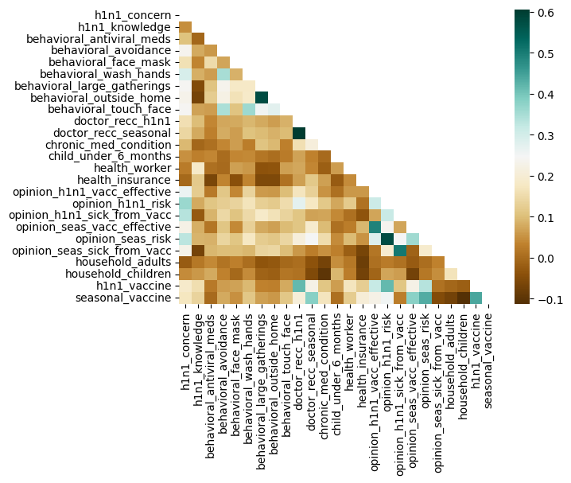

```python
# importing the necessary library
import seaborn as sns

# building the heatmap as a triangle for easier read
mask = np.triu(np.ones_like(j_train.corr(), dtype=np.bool))
sns.heatmap(j_train.corr(), mask=mask, cmap='BrBG')
```

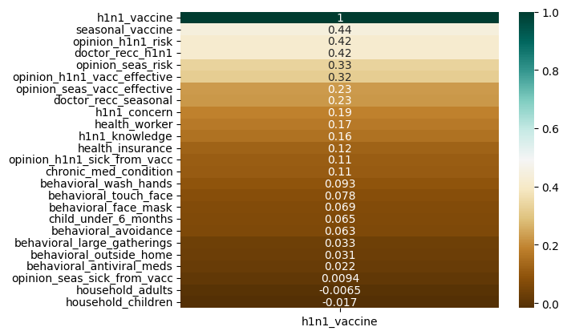

```python
# correlation of all features with 'h1n1_vaccine'
sns.heatmap(j_train.corr()[['h1n1_vaccine']].sort_values
            (by='h1n1_vaccine', ascending=False), annot=True, cmap='BrBG')
```

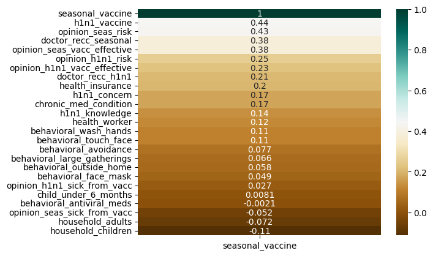

```python
# correlation of all features with 'seasonal_vaccine'
sns.heatmap(j_train.corr()[['seasonal_vaccine']].sort_values
            (by='seasonal_vaccine', ascending=False), annot=True, cmap='BrBG')
```

There is a quite strong correlation between H1N1 vaccination feature and the opinion of the patient regarding the risk, effectiveness and doctor recommendation. The same goes for the seasonal flu vaccination.

Looking also at the rate of vaccination for each level of h1n1_concern

```python
# creating a dataframe with h1n1_concern and h1n1_vaccine
counts = (j_train_back[['h1n1_concern', 'h1n1_vaccine']]
         .groupby(['h1n1_concern', 'h1n1_vaccine'])
         .size()
         .unstack('h1n1_vaccine')
         )
counts
```

| h1n1_vaccine h1n1_concern | 0 | 1 |
| --- | --- | --- |
| 0.0 | 2849 | 447 |
| 1.0 | 6756 | 1397 |
| 2.0 | 8102 | 2473 |
| 3.0 | 3250 | 1341 |

```python
# creating the rate of h1n1 vaccination per h1n1 concern shown by the patient
h1n1_concern_counts = counts.sum(axis='columns')
h1n1_concern_counts
```

```
h1n1_concern
0.0     3296
1.0     8153
2.0    10575
3.0     4591
dtype: int64
```

```python
props = counts.div(h1n1_concern_counts, axis='index')
props
```

| h1n1_vaccine h1n1_concern | 0 | 1 |
| --- | --- | --- |
| 0.0 | 0.864381 | 0.135619 |
| 1.0 | 0.828652 | 0.171348 |
| 2.0 | 0.766147 | 0.233853 |
| 3.0 | 0.707907 | 0.292093 |

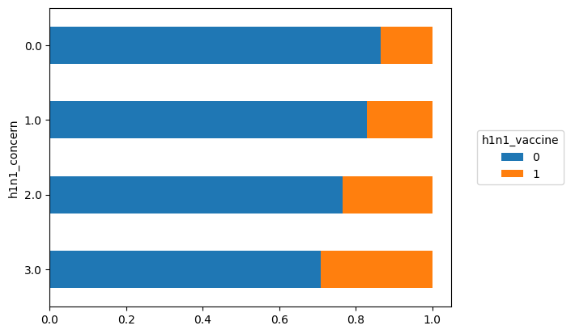

```python
# plotting the rate
ax = props.plot.barh(stacked=True)
ax.invert_yaxis()
ax.legend(
    loc='center left',
    bbox_to_anchor=(1.05, 0.5),
    title='h1n1_vaccine'
)
```

Clearly, even if most people don't get the H1N1 vaccine, they are more likely to if they have a higher level of concern. It would be easier to see this for all variables

```python
def vaccination_rate_plot(col, target, data, ax=None):
    counts = (j_train_back[[target, col]]
                  .groupby([target, col])
                  .size()
                  .unstack(target)
             )
    group_counts = counts.sum(axis='columns')
    props = counts.div(group_counts, axis='index')

    props.plot(kind="barh", stacked=True, ax=ax)
    ax.invert_yaxis()
    ax.legend().remove()
```

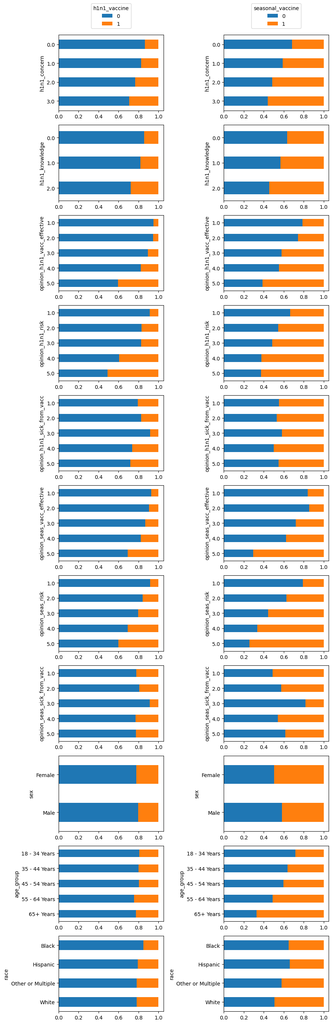

```python
cols_to_plot = [
    'h1n1_concern',
    'h1n1_knowledge',
    'opinion_h1n1_vacc_effective',
    'opinion_h1n1_risk',
    'opinion_h1n1_sick_from_vacc',
    'opinion_seas_vacc_effective',
    'opinion_seas_risk',
    'opinion_seas_sick_from_vacc',
    'sex',
    'age_group',
    'race',
]

fig, ax = plt.subplots(
    len(cols_to_plot), 2, figsize=(9,len(cols_to_plot)*2.5)
)
for idx, col in enumerate(cols_to_plot):
    vaccination_rate_plot(
        col, 'h1n1_vaccine', j_train_back, ax=ax[idx, 0]
    )
    vaccination_rate_plot(
        col, 'seasonal_vaccine', j_train_back, ax=ax[idx, 1]
    )

ax[0, 0].legend(
    loc='lower center', bbox_to_anchor=(0.5, 1.05), title='h1n1_vaccine'
)
ax[0, 1].legend(
    loc='lower center', bbox_to_anchor=(0.5, 1.05), title='seasonal_vaccine'
)
fig.tight_layout()
```

Now Building the model

```python
# Importing the libraries
from sklearn.preprocessing import StandardScaler
from sklearn.impute import SimpleImputer
from sklearn.compose import ColumnTransformer

from sklearn.linear_model import LogisticRegression
from xgboost import XGBClassifier
from sklearn.ensemble import RandomForestClassifier

from sklearn.ensemble import VotingClassifier

from sklearn.multioutput import MultiOutputClassifier

from sklearn.pipeline import Pipeline

from sklearn.model_selection import train_test_split

from sklearn.metrics import roc_curve, roc_auc_score
from sklearn.metrics import accuracy_score
```

Save all numerical columns into a single variable

```python
numeric_cols = f_train.columns[f_train.dtypes != "object"].values
```

Now calling the classifiers used for the prediction model. We will develop a multi output classifier that will include 3 different models to evaluate performance at best

```python
model_1 = LogisticRegression()
model_2 = XGBClassifier()
model_3 = RandomForestClassifier()
```

Now creating the pipeline. It is much easier to work with machine learning when using a pipeline. In this case, the pipelinne will use ColumnTransformer() to transform the columns and the estimators will be 3 in total using MultiOutputClassifier

```python
numeric_preprocessing_steps = Pipeline([
    ('standard_scaler', StandardScaler()),
    ('simple_imputer', SimpleImputer(strategy='median'))
])

# this will be the column transformer
preprocessor = ColumnTransformer(
    transformers = [
        ("numeric", numeric_preprocessing_steps, numeric_cols)
    ],
    remainder = "drop"
)


# these are the 3 model classifiers included as estimators
estimators = MultiOutputClassifier(
    VotingClassifier(estimators=[('lr', model_1), ('xgb', model_2), ('rf', model_3)], voting ='soft')
)


# this is the final pipeline
full_pipeline = Pipeline([
    ("preprocessor", preprocessor),
    ("estimators", estimators),
])
```

Now training the multi-output classifier and make a prediction

```python
X_train, X_eval, y_train, y_eval = train_test_split(
                                                    f_train,
                                                    l_train,
                                                    test_size=0.33,
                                                    shuffle=True,
                                                    stratify=l_train,
                                                    random_state=101
                                                    )
```

```python
full_pipeline.fit(X_train, y_train)
```

```
Pipeline(steps=[('preprocessor',
                 ColumnTransformer(transformers=[('numeric',
                                                  Pipeline(steps=[('standard_scaler',
                                                                   StandardScaler()),
                                                                  ('simple_imputer',
                                                                   SimpleImputer(strategy='median'))]),
                                                  array(['h1n1_concern', 'h1n1_knowledge', 'behavioral_antiviral_meds',
       'behavioral_avoidance', 'behavioral_face_mask',
       'behavioral_wash_hands', 'behavioral_large_gatherings',
       '...
                                                                                             interaction_constraints=None,
                                                                                             learning_rate=None,
                                                                                             max_bin=None,
                                                                                             max_cat_threshold=None,
                                                                                             max_cat_to_onehot=None,
                                                                                             max_delta_step=None,
                                                                                             max_depth=None,
                                                                                             max_leaves=None,
                                                                                             min_child_weight=None,
                                                                                             missing=nan,
                                                                                             monotone_constraints=None,
                                                                                             n_estimators=100,
                                                                                             n_jobs=None,
                                                                                             num_parallel_tree=None,
                                                                                             predictor=None,
                                                                                             random_state=None, ...)),
                                                                              ('rf',
                                                                               RandomForestClassifier())],
                                                                  voting='soft')))])
```

```python
full_pipeline.score(X_train, y_train)
```

```
0.8341809646230369
```

```python
preds = full_pipeline.predict_proba(X_eval)
```

Creating a dataframe with the predictions for both H1N1 and Seasonal vaccines

```python
y_preds = pd.DataFrame(
    {
        "h1n1_vaccine": preds[0][:, 1],
        "seasonal_vaccine": preds[1][:, 1],
    },
    index = y_eval.index
)
```

Calculating the ROC AUC Score and the accuracy score for the model

```python
roc_auc_score(y_eval, y_preds)
```

```
0.8378061125549063
```

```python
y_preds = (y_preds > 0.5)
accuracy_score(y_eval, y_preds)
```

```
0.6663262990696619
```

Now use the model to make predictions on the test data

```python
full_pipeline.fit(f_train, l_train)
None


f_test = pd.read_csv('./data/test_set_features.csv', index_col=0)
test_probas = full_pipeline.predict_proba(f_test)
submission_df = pd.read_csv('./data/submission_format.csv', index_col=0)

np.testing.assert_array_equal(f_test.index.values,
                              submission_df.index.values)

# Save predictions to submission data frame
submission_df["h1n1_vaccine"] = test_probas[0][:, 1]
submission_df["seasonal_vaccine"] = test_probas[1][:, 1]
submission_df.to_csv('my_submission.csv', index=True)
```

```python
submission_df.head()
```

| respondent_id | h1n1_vaccine | seasonal_vaccine |
| --- | --- | --- |
| 26707 | 0.107107 | 0.501131 |
| 26708 | 0.027803 | 0.027211 |
| 26709 | 0.435976 | 0.728089 |
| 26710 | 0.671742 | 0.874127 |
| 26711 | 0.325926 | 0.553847 |